# Robust Methods Lab

# Lab 1-Robust Methods

## Instructions

- If you are fitting a model, display the model output in a neatly formatted table. (The `gt` `tidy` and `kable` functions can help!)
- If you are creating a plot, use `ggplot` or `base`and make sure they are publication ready. That means there are clear labels for all axes, titles, etc.
- Commit and push your work to GitHub regularly, at least after each exercise. Write short and informative commit messages.
- When you’re done, we should be able to knit the final version of the QMD in your GitHub as a HTML.

```r
library(tidyverse)
library(robustbase) # star data
library(boot) # bootstrapping
library(correlation) # get different correlations
library(permuco) # run permutation tests
library(parameters) # SE
library(data.table) # fread
library(infer) # sample_rep_n function
library(palmerpenguins) # penguins dataset
library(reticulate)
use_condaenv('base')
```

## Robust Correlations

Use the `stars` data in `robustbase`. This data looks at the relationship between temperature at the surface of a star and the light intensity.

```r
# load the stars database
stars<-robustbase::starsCYG

# read in the data set to python as well
head(stars)
```

```
##   log.Te log.light
## 1   4.37      5.23
## 2   4.56      5.74
## 3   4.26      4.93
## 4   4.56      5.74
## 5   4.30      5.19
## 6   4.46      5.46
```

a. Plot the data and describe the pattern seen. What is Pearson’s *r*?

*We can see that some outliers with a low log temperature are changing the dominant relationship log temperature and log light.*

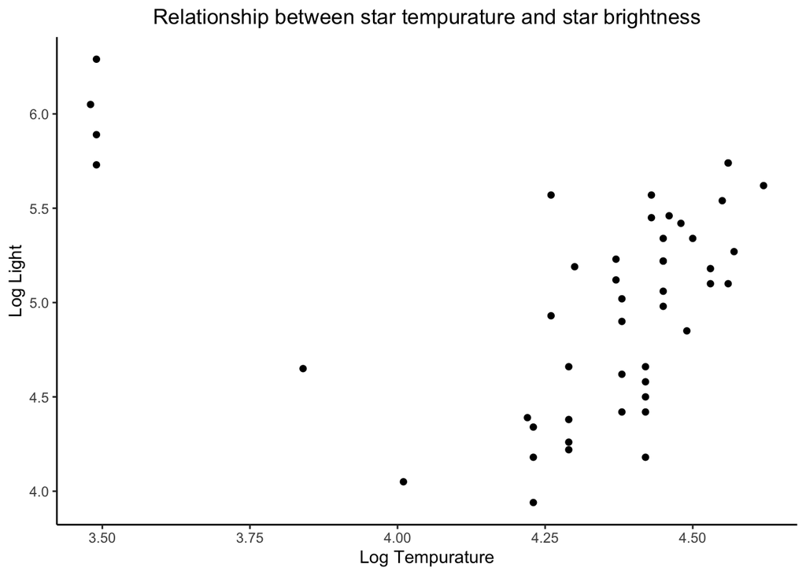

```r
# plot the data
ggplot(stars, aes(x=log.Te, y=log.light)) + geom_point() + labs(title="Relationship between star tempurature and star brightness", x="Log Tempurature", y = "Log Light") + theme_classic() + theme(plot.title = element_text(hjust = 0.5))
```

```r
# Calculate Pearson Correlation Coefficient
correlation = cor(stars$log.Te, stars$log.light)
correlation
```

```
## [1] -0.2104133
```

b. Re-run the correlation, but this time use the winsorized r (20%). Do this manually and then with the correlation::correlation function from `easystats`.

*We can see that r changes to a slightly positive value from a negative one. If we plot, we can see that we have cut the outliers that were causing the negative correlation.*

```r
# let's windsorize the data by 20%
stars_trim_20 = datawizard::winsorize(stars, threshold=0.2, method='percentile')

# recalculate r
correlation_trim = cor(stars_trim_20$log.Te, stars_trim_20$log.light)
correlation_trim
```

```
## [1] 0.3444762
```

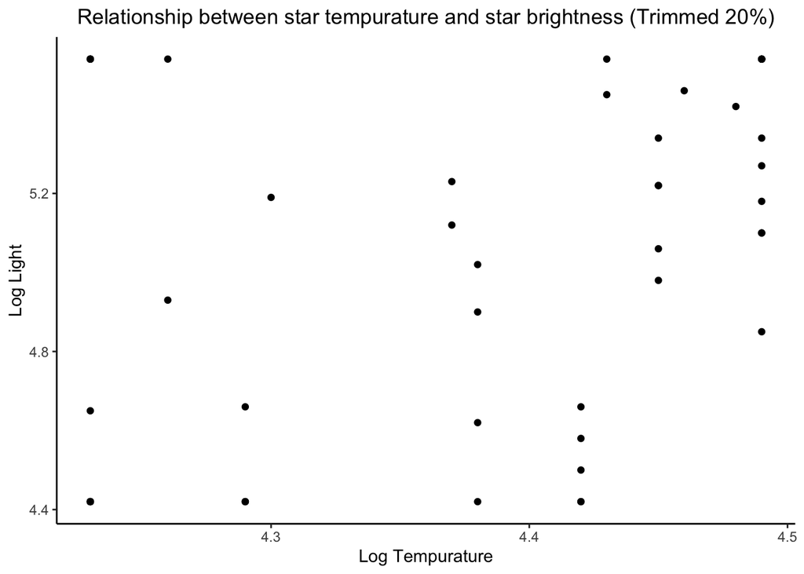

```r
# plot the data
ggplot(stars_trim_20, aes(x=log.Te, y=log.light)) + geom_point() + labs(title="Relationship between star tempurature and star brightness (Trimmed 20%)", x="Log Tempurature", y = "Log Light") + theme_classic() + theme(plot.title = element_text(hjust = 0.5))
```

```r
# We can also calculate it this way
correlation::correlation(stars, winsorize=0.2)
```

```
## # Correlation Matrix (pearson-method)
##
## Parameter1 | Parameter2 |    r |       95% CI | t(45) |      p
## --------------------------------------------------------------
## log.Te     |  log.light | 0.34 | [0.06, 0.57] |  2.46 | 0.018*
##
## p-value adjustment method: Holm (1979)
## Observations: 47
```

c. Compare the correlations.

## Bootstrapping and Permutations

2. For the following data:
   $$8.453532,
   10.025041, 11.495339, 9.367600, 8.333229, 9.788753, 10.883344,
   10.543059, 9.869095, 10.799819$$

a. Bootstrap the mean (using the `boot` package) and plot the histogram with `ggplot2`

```r
set.seed(1234)
data = c(8.453532, 10.025041, 11.495339, 9.367600, 8.333229, 9.788753, 10.883344, 10.543059, 9.869095, 10.799819)

# define a mean function
mean_fun = function(data, indices) {
  return(mean(data[indices]))
} # end fun

results_mean = boot(data, mean_fun, R=1000)
results_mean
```

```
##
## ORDINARY NONPARAMETRIC BOOTSTRAP
##
##
## Call:
## boot(data = data, statistic = mean_fun, R = 1000)
##
##
## Bootstrap Statistics :
##     original      bias    std. error
## t1* 9.955881 0.003788918   0.3153823
```

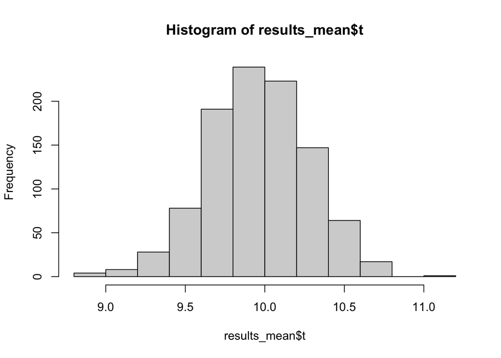

```r
# plot of histogram of the means
hist(results_mean$t)
```

b. Bootstrap the median (using the `boot` package) and plot the histogram with `ggplot2`

```r
# define a median function
med_fun = function(data, indices) {
  return(median(data[indices]))
} # end fun

results_med = boot(data, med_fun, R=1000)
results_med
```

```
##
## ORDINARY NONPARAMETRIC BOOTSTRAP
##
##
## Call:
## boot(data = data, statistic = med_fun, R = 1000)
##
##
## Bootstrap Statistics :
##     original     bias    std. error
## t1* 9.947068 0.08333787   0.4129688
```

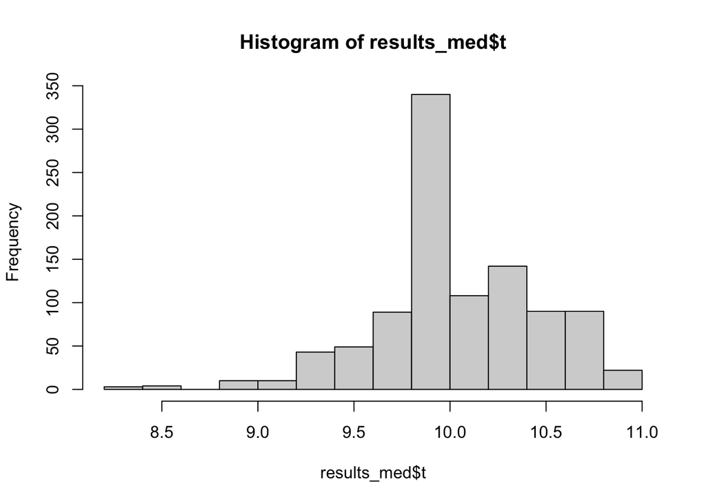

```r
# plot of histogram of the means
hist(results_med$t)
```

c. For the mean bootstraps, plot the 95% confidence intervals (percentile and bca) ) along with the mean. Use `geom_vline annotate` to mark the lines noting what they represent.

*T tried finding a way to extract the confidence interval from the `mean_results_ci` variable, but didn’t have any luck.*

```r
# calculate ci's
mean_results_ci = boot.ci(results_mean, type="perc", R=1000)
mean_results_ci
```

```
## BOOTSTRAP CONFIDENCE INTERVAL CALCULATIONS
## Based on 1000 bootstrap replicates
##
## CALL :
## boot.ci(boot.out = results_mean, type = "perc", R = 1000)
##
## Intervals :
## Level     Percentile
## 95%   ( 9.332, 10.564 )
## Calculations and Intervals on Original Scale
```

```r
# calculate the bac's
mean_results_bac = boot.ci(results_mean, type="bca", R=1000)
mean_results_bac
```

```
## BOOTSTRAP CONFIDENCE INTERVAL CALCULATIONS
## Based on 1000 bootstrap replicates
##
## CALL :
## boot.ci(boot.out = results_mean, type = "bca", R = 1000)
##
## Intervals :
## Level       BCa
## 95%   ( 9.259, 10.526 )
## Calculations and Intervals on Original Scale
```

[figure not shown]

```r
# plot of histogram of the means
ggplot(data.frame(results_mean$t), aes(x=results_mean.t)) +
  geom_histogram(color='black',fill='white') +
  geom_vline(xintercept = c(9.332, 10.564, 9.259, 10.526), color=c('magenta','magenta','cyan','cyan'), size=2) +
  annotate('text', x=c(9.1, 10.35, 9.5, 10.75), y=c(150,150,150,150), label=c('CI Lower','CI Upper', 'BCA Lower','BCA Upper')) +
  labs(title='Bootstrapped Mean Estimates with 95% Intervals', x='Mean Estimates', y='Count')
```

d. For the median bootstraps, plot the 95% confidence intervals (Percentile and BCa). Use `geom_vline and annotate` to mark the lines noting what they represent.

```r
# calculate ci's
med_results_ci = boot.ci(results_med, type="perc", R=1000)
med_results_ci
```

```
## BOOTSTRAP CONFIDENCE INTERVAL CALCULATIONS
## Based on 1000 bootstrap replicates
##
## CALL :
## boot.ci(boot.out = results_med, type = "perc", R = 1000)
##
## Intervals :
## Level     Percentile
## 95%   ( 9.121, 10.800 )
## Calculations and Intervals on Original Scale
```

```r
# calculate the bac's
med_results_bac = boot.ci(results_med, type="bca", R=1000)
med_results_bac
```

```
## BOOTSTRAP CONFIDENCE INTERVAL CALCULATIONS
## Based on 1000 bootstrap replicates
##
## CALL :
## boot.ci(boot.out = results_med, type = "bca", R = 1000)
##
## Intervals :
## Level       BCa
## 95%   ( 8.911, 10.713 )
## Calculations and Intervals on Original Scale
```

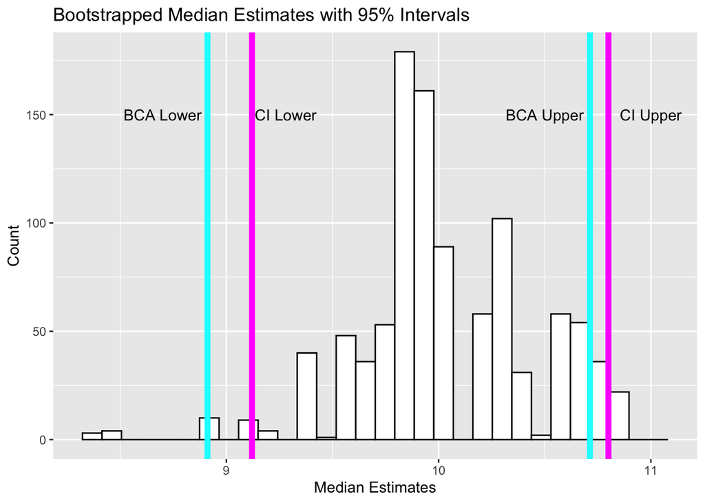

```r
# plot of histogram of the means
ggplot(data.frame(results_med$t), aes(x=results_med.t)) +
  geom_histogram(color='black',fill='white') +
  geom_vline(xintercept = c(9.121, 10.8, 8.911, 10.713), color=c('magenta','magenta','cyan','cyan'), size=2) +
  annotate('text', x=c(9.28, 11, 8.7, 10.5), y=c(150,150,150,150), label=c('CI Lower','CI Upper', 'BCA Lower','BCA Upper')) +
  labs(title='Bootstrapped Median Estimates with 95% Intervals', x='Median Estimates', y='Count')
```

3. You want to test whether the following paired samples are significantly different from one another: pre =
   $$22,25,17,24,16,29,20,23,19,20$$
   , post =
   $$18,21,16,22,19,24,17,21,23,18$$
   . Often researchers would run a paired sampled t-test, but you are concerned the data does not follow a normal distribution.
1. Calculate the paired differences, that is post - pre, which will result in a vector of paired differences (pdiff0 = post - pre)

```r
v1 = c(22,25,17,24,16,29,20,23,19,20)
v2 = c(18,21,16,22,19,24,17,21,23,18)
pdiff0 = v2 - v1
pdiff0
```

```
##  [1] -4 -4 -1 -2  3 -5 -3 -2  4 -2
```

b. Calculate the mean of the paired differences (Xpdiff0)

```r
mean(pdiff0)
```

```
## [1] -1.6
```

d. Bootstrap b) with replacement (pdiff1) and plot the histogram with `ggplot2`.

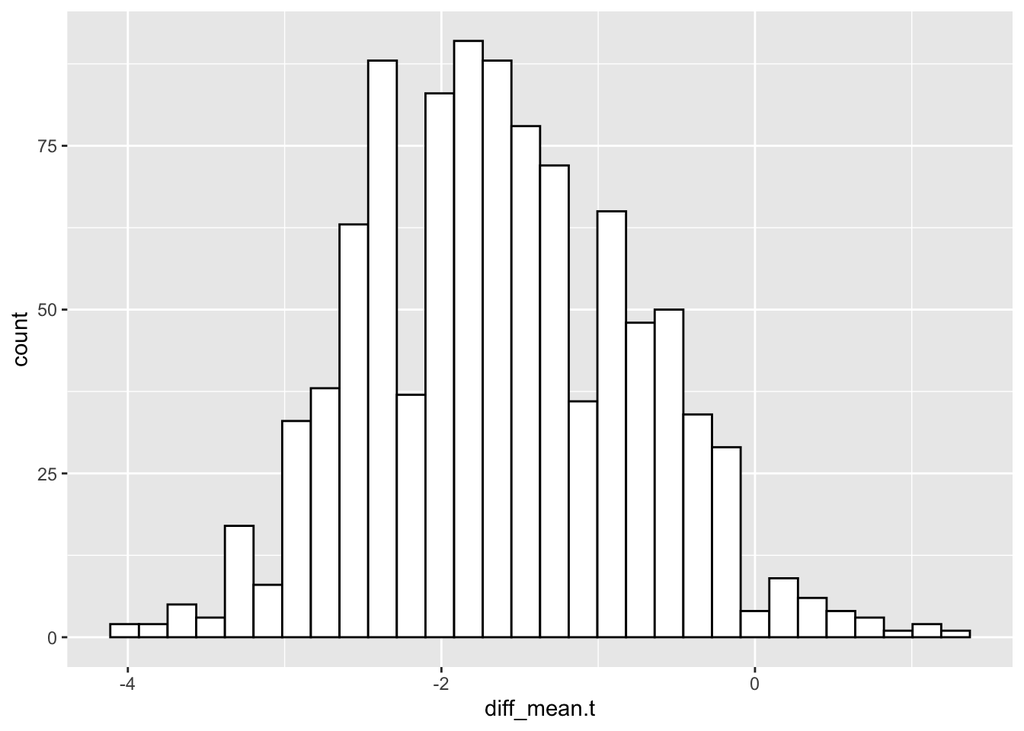

```r
diff_mean = boot(pdiff0, mean_fun, R=1000)

# plot of histogram of the means
ggplot(data.frame(diff_mean$t), aes(x=diff_mean.t)) +
  geom_histogram(color='black',fill='white')
```

e. Calculate the 95% confidence intervals (BCa). What can you infer from this?

*We can infer that the mean difference as a result of the treatment is not significantly different from zero.*

```r
diff_mean_bac = boot.ci(diff_mean, type="bca", R=1000)
diff_mean_bac
```

```
## BOOTSTRAP CONFIDENCE INTERVAL CALCULATIONS
## Based on 1000 bootstrap replicates
##
## CALL :
## boot.ci(boot.out = diff_mean, type = "bca", R = 1000)
##
## Intervals :
## Level       BCa
## 95%   (-3.000,  0.414 )
## Calculations and Intervals on Original Scale
```

f. Plot bootstrap mean along with 95% CIs (with `ggplot2`). Use annotate to note what the vertical lines represent.

[figure not shown]

```r
# plot of histogram of the means
ggplot(data.frame(diff_mean$t), aes(x=diff_mean.t)) +
  geom_histogram(color='black',fill='white') +
  geom_vline(xintercept = c(-3, 0.6), color=c('magenta','magenta'), size=2) +
  # annotate('text', x=c(9.28, 11, 8.7, 10.5), y=c(150,150,150,150), label=c('CI Lower','CI Upper', 'BCA Lower','BCA Upper')) +
  labs(title='Bootstrapped Mean Difference Estimates with 95% BCA Intervals', x='Mean Difference Estimates', y='Count')
```

4. Pepper Joe measured the length and heat of 85 chili peppers. He wants to know if smaller peppers are hotter than longer peppers.

*There aren’t additional questions here, so I’ll run the analysis I think that I should run.*

*And as demonstrated below, the mean relationship between length and hotness is significantly below zero!*

```r
#read data.table to read in
chili = read.delim("https://raw.githubusercontent.com/jgeller112/psy504-advanced-stats/main/slides/03-Robust_Methods/data/chillis.csv")
chili = select(chili, c('LENGTH','HEAT'))
head(chili)
```

```
##   LENGTH HEAT
## 1   5.00  5.0
## 2   7.50  7.0
## 3  11.43  7.5
## 4   3.81  9.0
## 5   6.00  2.0
## 6   6.35  7.0
```

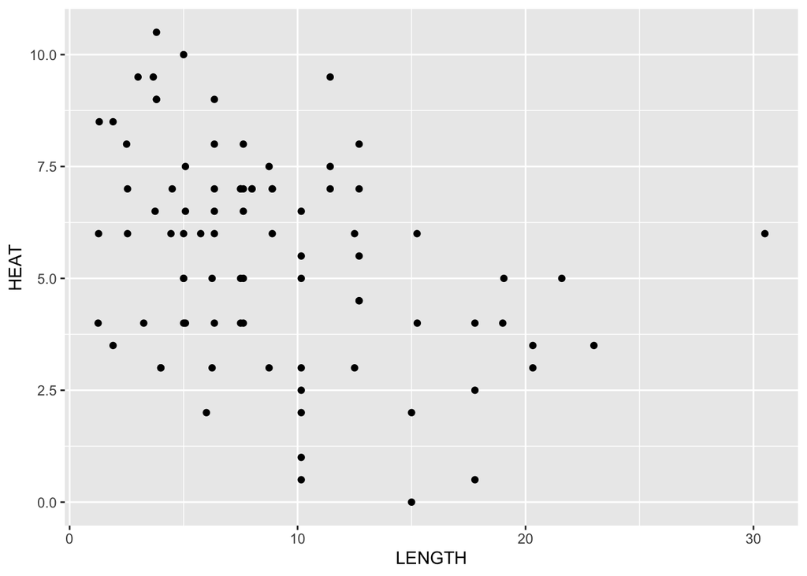

```r
# visualize the data
ggplot(chili, aes(x=LENGTH, y=HEAT)) +
  geom_point()
```

```r
# run our regression many times, and simulate the regression coefficient distribution between length and heat.

# a place to store the samples
sample_intercept = NULL
sample_x1 = NULL

for (i in 1:1000) {

  # create a bootstrapped sample of our data with replacement
  sample_data = chili[sample(1:nrow(chili), nrow(chili),replace=TRUE), ]

  # model the data
  boot_model = lm(HEAT ~ LENGTH, data=sample_data)

  # save the coefficients
  sample_intercept = append(sample_intercept, boot_model$coefficients[1])
  sample_x1 = append(sample_x1, boot_model$coefficients[[2]])

} # end for
```

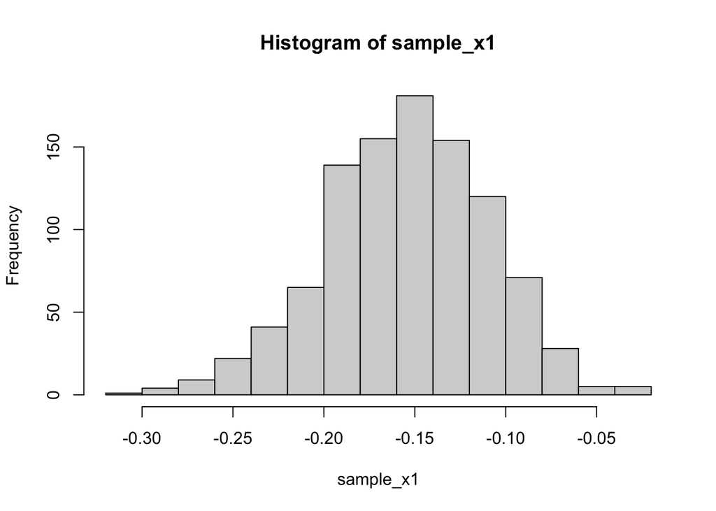

```r
hist(sample_x1)
```

```r
# we can define the above as a function

x1_fun = function(data, indices) {
  # create a bootstrapped sample of our data with replacement
  sample_data = chili[indices, ]

  # model the data
  boot_model = lm(HEAT ~ LENGTH, data=sample_data)
  return(boot_model$coefficients[[2]])

} # end fun

# compute the bootstrap
chili_x1 = boot(chili, x1_fun, R=1000)
```

```r
# we can now use the bootstrap to calc confidence intervals
x1_bac = boot.ci(chili_x1, type="bca", R=1000)
x1_bac
```

```
## BOOTSTRAP CONFIDENCE INTERVAL CALCULATIONS
## Based on 1000 bootstrap replicates
##
## CALL :
## boot.ci(boot.out = chili_x1, type = "bca", R = 1000)
##
## Intervals :
## Level       BCa
## 95%   (-0.2403, -0.0643 )
## Calculations and Intervals on Original Scale
```

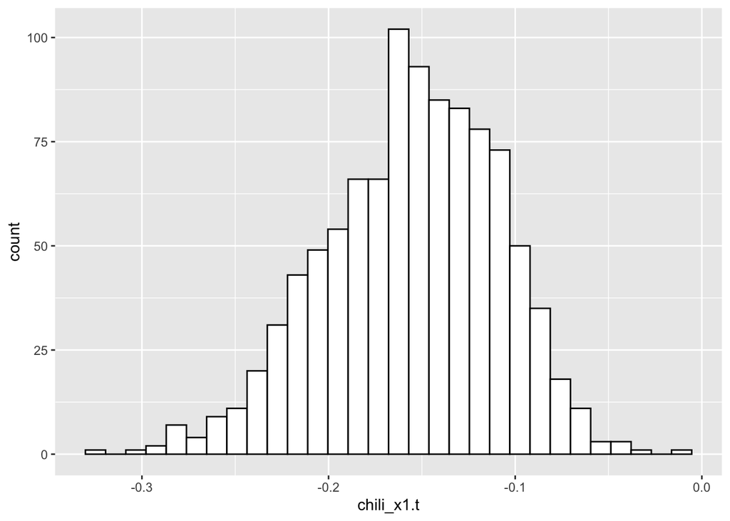

```r
ggplot(data.frame(chili_x1$t), aes(x=chili_x1.t)) +
  geom_histogram(color='black',fill='white')
```

```r
  #geom_vline(xintercept = c(-3, 0.6), color=c('magenta','magenta'), size=2) +
  # annotate('text', x=c(9.28, 11, 8.7, 10.5), y=c(150,150,150,150), label=c('CI Lower','CI Upper', 'BCA Lower','BCA Upper')) +
  #labs(title='Bootstrapped Mean Difference Estimates with 95% BCA Intervals', x='Mean Difference Estimates', y='Count')
```

5. Some species display sexual size dimorphism – in which one sex is on average larger than the other. Such a pattern can tell us about the species’ ecology and mating habits. Do penguins display this sex difference in size? Let’s just look at a subset of the palmerpenguins data set, which we’ll call `my_penguins`.

```r
my_penguins <- penguins %>%
  filter(species == "Adelie",
         !is.na(sex),
         island == "Torgersen")
my_penguins
```

```
## # A tibble: 47 × 8
##    species island    bill_length_mm bill_depth_mm flipper_length_mm body_mass_g
##    <fct>   <fct>              <dbl>         <dbl>             <int>       <int>
##  1 Adelie  Torgersen           39.1          18.7               181        3750
##  2 Adelie  Torgersen           39.5          17.4               186        3800
##  3 Adelie  Torgersen           40.3          18                 195        3250
##  4 Adelie  Torgersen           36.7          19.3               193        3450
##  5 Adelie  Torgersen           39.3          20.6               190        3650
##  6 Adelie  Torgersen           38.9          17.8               181        3625
##  7 Adelie  Torgersen           39.2          19.6               195        4675
##  8 Adelie  Torgersen           41.1          17.6               182        3200
##  9 Adelie  Torgersen           38.6          21.2               191        3800
## 10 Adelie  Torgersen           34.6          21.1               198        4400
## # ℹ 37 more rows
## # ℹ 2 more variables: sex <fct>, year <int>
```

a. Visualize body size by sex

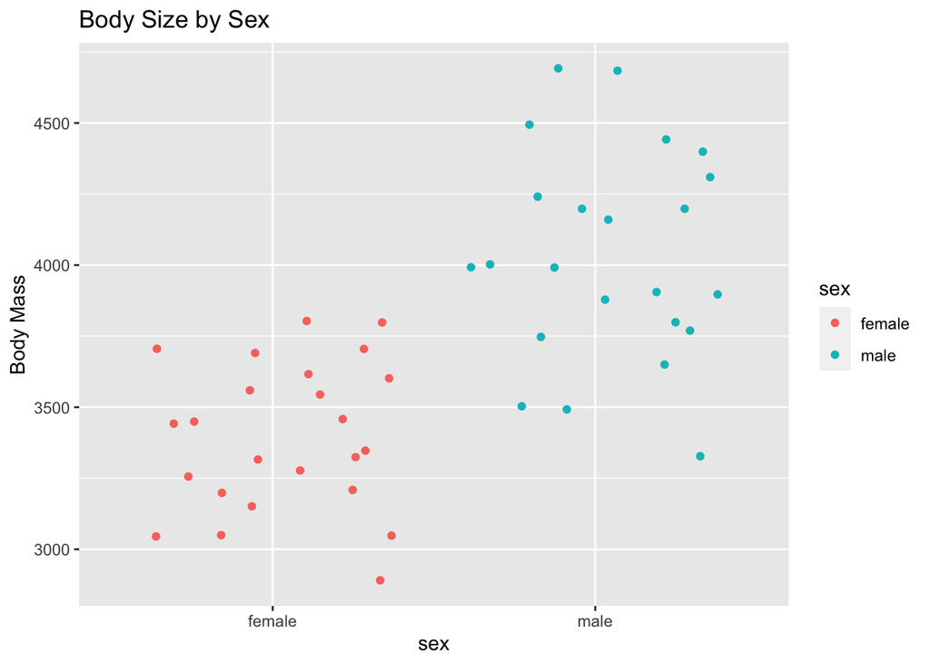

```r
ggplot(my_penguins, aes(x=sex, y=body_mass_g, color=sex)) +
  geom_jitter() +
  labs(title='Body Size by Sex', y='Body Mass')
```

b. Calculate the original mean difference between sex

```r
mean_diff_penguins = mean(filter(my_penguins, sex=='male')$body_mass_g) - mean(filter(my_penguins, sex=='female')$body_mass_g)
mean_diff_penguins
```

```
## [1] 638.9493
```

c. Permute the group labels (10000x)

```r
library(infer)

#sample_size = nrow(my_penguins)
##perm_reps = 10000
#permutation = my_penguins %>%
#  rep_sample_n(size = sample_size, replace = FALSE, reps = perm_reps) %>%
#  mutate(perm_treatment = sample(sex, size = n(), replace = FALSE)) %>%
#  group_by(sex)

#permutation

df_diff = my_penguins %>%
  specify(body_mass_g ~ sex) %>%
  calculate(stat = "diff in means")
null_distn  <- my_penguins   %>%
  specify(body_mass_g ~ sex) %>%
   hypothesize(null = "independence") %>%
   generate(reps = 10000, type = "permute") %>%
   calculate(stat = "diff in means")
```

d. Plot the null-hypothesis distribution (NHD) for the difference

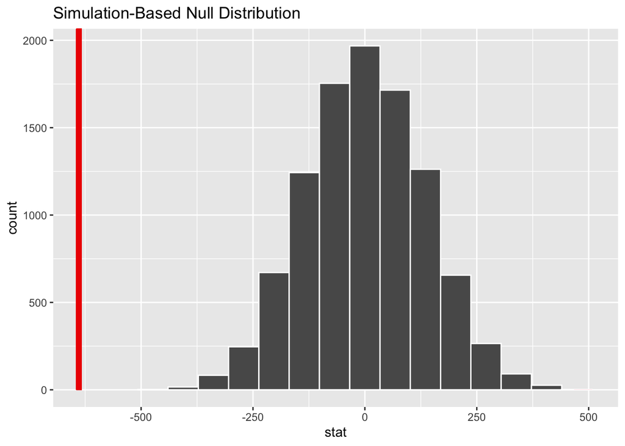

```r
null_distn %>%
  visualize() +shade_p_value(obs_stat = df_diff, direction = "two-sided")
```

e. Compare the observed mean difference to the NHD (is *p* < .05?)

*In this case, the p value is so small, it has been rounded to zero. Needless to say, our results are very significant!*

```r
null_distn %>%
  get_p_value(obs_stat = df_diff, direction = "two-sided")
```

```
## # A tibble: 1 × 1
##   p_value
##     <dbl>
## 1       0
```

6. Suppose a replication experiment was conducted to further examine the interaction effect between driving difficulty and conversation difficulty on driving errors in a driving simulator. In the replication, the researchers administered the same three levels of conversation difficulty; (1) control, (2) easy, (3) difficult (C, E, D) but assume that they added a third level of driving difficulty; (1) low, (2) moderate, (3) difficult (L, M, D). Assume the design was completely between subjects and conduct a factorial ANOVA to test the main effects of conversation and driving difficulty as well as the interaction effect. The DV is the number of errors committed in the driving simulator.

   ```r
   library(tidyverse)
   fac_data<-read_csv("https://raw.githubusercontent.com/jgeller112/psy503-psych_stats/master/static/assignment/data/fact_final.csv")
   ```

a. Run a permutation test (ANOVA)

b. How would you follow-up significant effects in this context?

## Robust Linear Models

7. Suppose we have the following data frame in R that contains information on the hours studied and exam score received by 20 students in some class:

```r
df <- data.frame(hours=c(1, 1, 1, 1, 2, 2, 2, 3, 3, 3, 4,
                         4, 5, 5, 5, 6, 6, 7, 7, 8),
                 score=c(67, 68, 74, 70, 71, 75, 80, 70, 84, 72,
                         88, 75, 95, 75, 99, 78, 99, 65, 96, 70))
```

a. Use the lm() function to fit a regression model in R that uses **hours** as the predictor variable and **score** as the response variable

```r
study_lm = lm(score ~ hours, data=df)
summary(study_lm)
```

```
##
## Call:
## lm(formula = score ~ hours, data = df)
##
## Residuals:
##     Min      1Q  Median      3Q     Max
## -19.775  -5.298  -3.521   7.520  18.116
##
## Coefficients:
##             Estimate Std. Error t value Pr(>|t|)
## (Intercept)   71.158      4.708   15.11 1.14e-11 ***
## hours          1.945      1.075    1.81    0.087 .
## ---
## Signif. codes:  0 '***' 0.001 '**' 0.01 '*' 0.05 '.' 0.1 ' ' 1
##
## Residual standard error: 10.48 on 18 degrees of freedom
## Multiple R-squared:  0.154,  Adjusted R-squared:  0.107
## F-statistic: 3.278 on 1 and 18 DF,  p-value: 0.08696
```

b. Interpret the results

c. Check assumptions and report which ones failed (include plots)

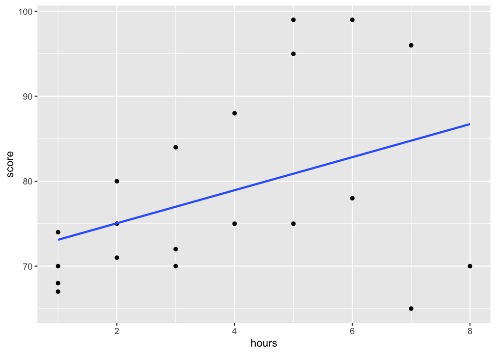

```r
library(tidyverse)
library(broom)
metrics = augment(study_lm)
ggplot(metrics, aes(x=hours, y=score)) +
  geom_point() +
  stat_smooth(method = lm, se = FALSE)
```

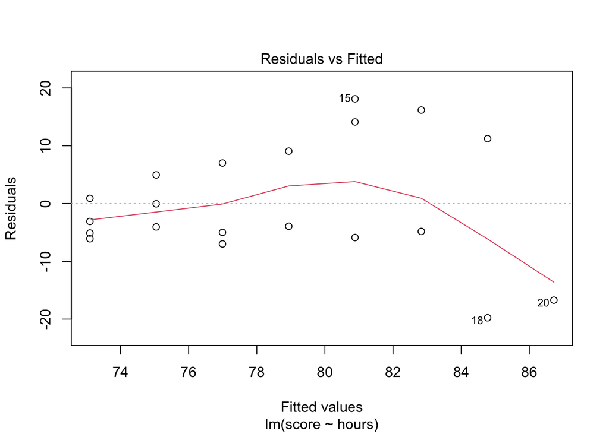

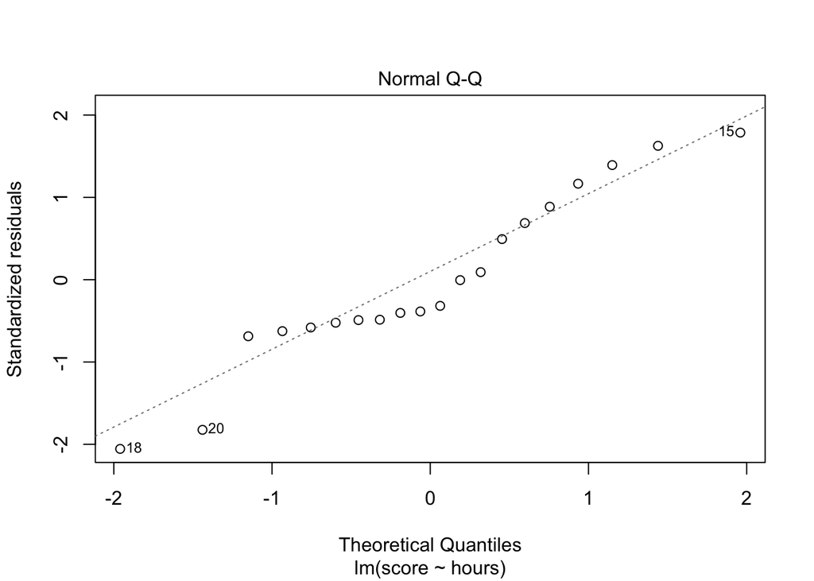

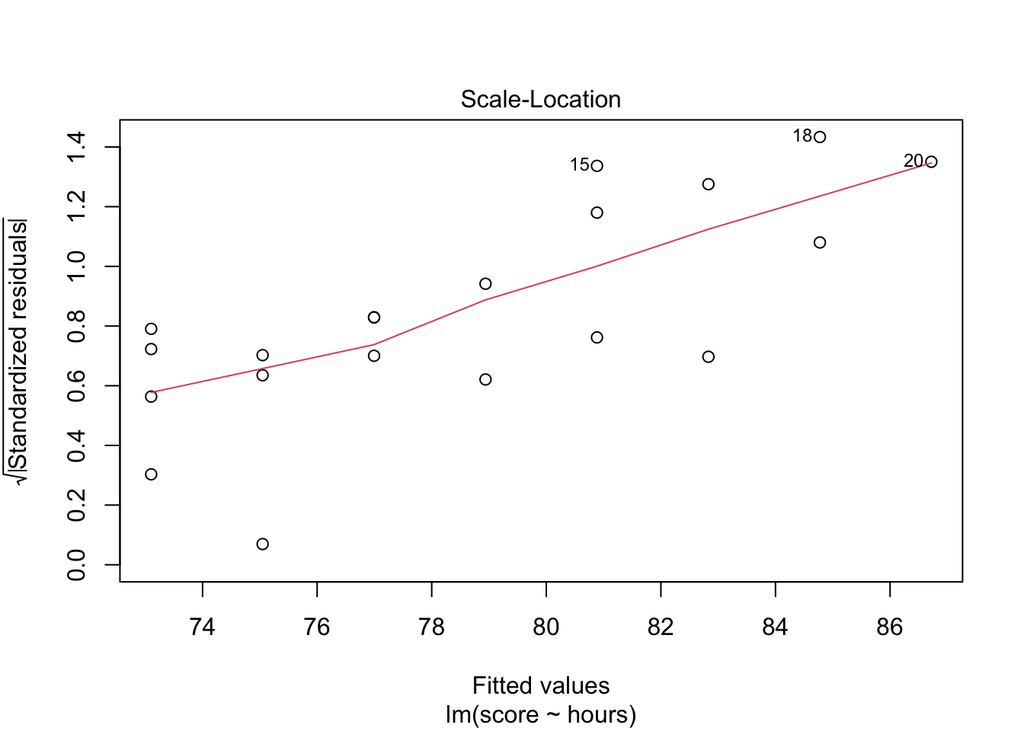

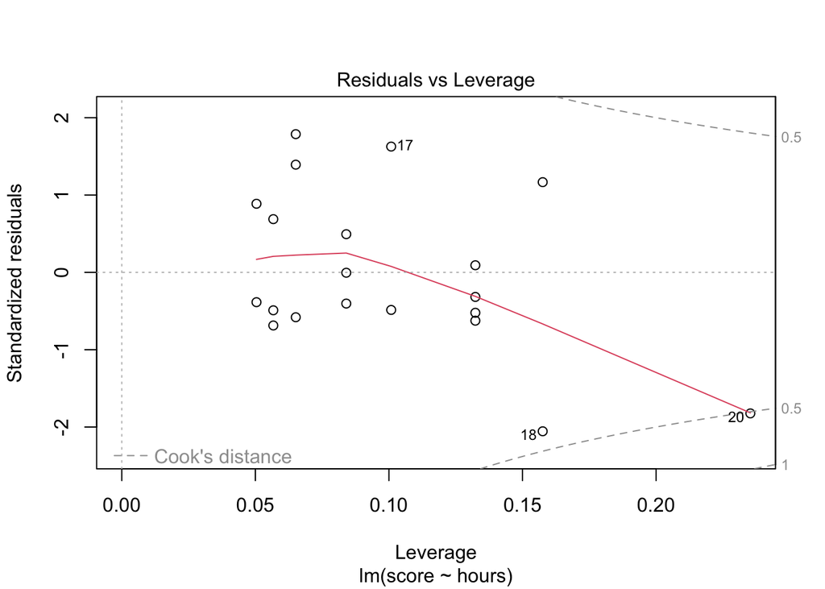

```r
plot(study_lm)
```

d. Re-run the lm you saved above, but with robust standard errors

```r
library(estimatr)
robust_study_model = lm_robust(score ~ hours, data=df, se_type="HC3")
tidy(robust_study_model)
```

```
##          term  estimate std.error statistic      p.value  conf.low conf.high df
## 1 (Intercept) 71.157563  3.991352 17.827936 6.939535e-13 62.772044  79.54308 18
## 2       hours  1.945378  1.468466  1.324769 2.018213e-01 -1.139754   5.03051 18
##   outcome
## 1   score
## 2   score
```

```r
library(easystats)
check_heteroscedasticity(robust_study_model)
```

```
## OK: Error variance appears to be homoscedastic (p = 0.974).
```

e. What differences do you notice between the regular regression and the regression with robust SEs applied?

```r
tidy(robust_study_model)
```

```
##          term  estimate std.error statistic      p.value  conf.low conf.high df
## 1 (Intercept) 71.157563  3.991352 17.827936 6.939535e-13 62.772044  79.54308 18
## 2       hours  1.945378  1.468466  1.324769 2.018213e-01 -1.139754   5.03051 18
##   outcome
## 1   score
## 2   score
```

```r
tidy(study_lm)
```

```
## # A tibble: 2 × 5
##   term        estimate std.error statistic  p.value
##   <chr>          <dbl>     <dbl>     <dbl>    <dbl>
## 1 (Intercept)    71.2       4.71     15.1  1.14e-11
## 2 hours           1.95      1.07      1.81 8.70e- 2
```